# outcome_var_prep

2026-08-28

# Deservingness Scores

Standardize? No – in my prelim, I write: To ensure that I do not control for a variable that is conceptually or empirically too close to the deservingness of incarcerated people when it is the dependent variable, I exclude any deservingness ratings for groups that are substantively overlapping or highly correlated. Including those could absorb variance in the outcome or introduce post-treatment bias by controlling for a related evaluative construct. I also avoid using global composite or average deservingness scores across all groups – for example, a respondent’s mean deservingnesss rating across all 65 groups they evaluated – because that composite would include the rating of incarcerated people itself, introducing potential collinearity and making it difficult to isolate the unique effect of contact. This modeling strategy attempts to preserve interpretability and ensuring that the effect of policy contact is estimated with respect to unstandardized, target-specific deservingness scores. 12

12 While constructing composite or control variables involving other deservingness targets, I assess whether their inclusion introduces collinearity or conceptual overlap with the dependent variable. In particular, I examine correlations between group-level deservingness ratings to ensure that any included groups are not too closely tied to perceptions of incarcerated people. If preliminary checks reveal that including a particular group (e.g., “criminals” or “formerly incarcerated individuals”) would obscure key variance or conflate target constructs, I exclude it from the model and treat it as conceptually non-distinct for the purposes of this analysis.

## B. Sympathy “desor_core” control

# Policy Preferences

## Dpen & LWOP

Takeaway: prison pen, prison pen 1 = dpen, prison pen 5 = lwop now -confirmed that prisonpen works – constructed with average of death penalty and lwop. USE dpen_rev and lwop_rev and prisonpen.

### CBA & Corr

[output not shown]

results - The **correlation** between the two items is **r = 0.238**.

- With only two items, Cronbach’s alpha is essentially a rescaled version of that correlation. (So don’t oversell alpha here; the correlation is the clean summary.)

Interpretation

### Visual

[output not shown]

|  | raw_alpha | std.alpha | G6(smc) | average_r | S/N | alpha se | var.r | med.r |
| --- | --- | --- | --- | --- | --- | --- | --- | --- |
| d_welfare_tanf_abc | 0.8981096 | 0.9018212 | 0.8950305 | 0.5675140 | 9.185496 | 0.003320279 | 0.008122103 | 0.5860116 |
| d_fstamps_snap_abc | 0.8968396 | 0.9002058 | 0.8938366 | 0.5630633 | 9.020627 | 0.003351290 | 0.007136222 | 0.5860116 |
| d_medicaid_abc | 0.9001476 | 0.9024131 | 0.8966486 | 0.5691586 | 9.247279 | 0.003229935 | 0.008488496 | 0.5786622 |
| d_medicare_abc | 0.9079059 | 0.9107023 | 0.9049170 | 0.5929878 | 10.198500 | 0.002997103 | 0.007837140 | 0.6026759 |
| d_unemployed_abc | 0.9025293 | 0.9058935 | 0.9027213 | 0.5789792 | 9.626258 | 0.003174931 | 0.009817560 | 0.5953453 |
| d_poorfam_abc | 0.9013837 | 0.9038294 | 0.8984608 | 0.5731236 | 9.398187 | 0.003196160 | 0.008731428 | 0.5860116 |
| d_homeless_abc | 0.9025702 | 0.9057801 | 0.9013249 | 0.5786551 | 9.613470 | 0.003167871 | 0.009101690 | 0.5860116 |
| d_immigrants_abc | 0.9188270 | 0.9194730 | 0.9150559 | 0.6199410 | 11.418191 | 0.002617017 | 0.003857696 | 0.6241707 |

|  | n | raw.r | std.r | r.cor | r.drop | mean | sd |
| --- | --- | --- | --- | --- | --- | --- | --- |
| d_welfare_tanf_abc | 2220 | 0.8410607 | 0.8381453 | 0.8210951 | 0.7827178 | 64.38063 | 25.43572 |
| d_fstamps_snap_abc | 2225 | 0.8523189 | 0.8528313 | 0.8400537 | 0.7995800 | 69.65258 | 24.28748 |
| d_medicaid_abc | 2224 | 0.8249342 | 0.8327186 | 0.8104545 | 0.7678437 | 72.53642 | 22.29876 |
| d_medicare_abc | 2225 | 0.7445962 | 0.7540904 | 0.7083409 | 0.6667368 | 76.39865 | 22.07437 |
| d_unemployed_abc | 2220 | 0.8030802 | 0.8003139 | 0.7621509 | 0.7324478 | 65.35721 | 24.99779 |
| d_poorfam_abc | 2225 | 0.8118630 | 0.8196357 | 0.7927272 | 0.7531387 | 76.49483 | 22.05169 |
| d_homeless_abc | 2225 | 0.8026659 | 0.8013832 | 0.7667815 | 0.7319525 | 69.65933 | 24.95843 |
| d_immigrants_abc | 2220 | 0.6802725 | 0.6651537 | 0.5858433 | 0.5642783 | 61.64550 | 27.72060 |

```
[[1]]
[1] "d_welfare_tanf_abc" "d_fstamps_snap_abc" "d_medicaid_abc"     "d_medicare_abc"
[5] "d_unemployed_abc"   "d_poorfam_abc"      "d_homeless_abc"     "d_immigrants_abc"
```

## Prison Help

### Descriptive

```
   Min. 1st Qu.  Median    Mean 3rd Qu.    Max.     NAs
   0.00   55.00   69.75   69.50   85.00  100.00      94
   Min. 1st Qu.  Median    Mean 3rd Qu.    Max.     NAs
-3.6145 -0.7541  0.0130  0.0000  0.8061  1.5862      94
```

### CBA & Corr

```
   Min. 1st Qu.  Median    Mean 3rd Qu.    Max.     NAs
-99.000   2.000   4.000   3.665   5.000   7.000     296
```

## Election Items

### Jail voting, rights restoration

[output not shown]

[output not shown]

```
    95% confidence boundaries
```

|  | lower | alpha | upper |
| --- | --- | --- | --- |
| Feldt | 0.33 | 0.38 | 0.43 |
| Duhachek | 0.33 | 0.38 | 0.43 |

```
 Reliability if an item is dropped:
```

|  | raw_alpha | std.alpha | G6(smc) | average_r | S/N | alpha se | var.r | med.r |
| --- | --- | --- | --- | --- | --- | --- | --- | --- |
| dpen_rev | 0.2755785 | 0.2377258 | 0.05651355 | 0.2377258 | 0.3118639 | NA | 0 | 0.2377258 |
| lwop_rev | 0.2050724 | 0.2377258 | 0.05651355 | 0.2377258 | 0.3118639 | NA | 0 | 0.2377258 |

```
 Item statistics
```

|  | n | raw.r | std.r | r.cor | r.drop | mean | sd |
| --- | --- | --- | --- | --- | --- | --- | --- |
| dpen_rev | 2030 | 0.8210325 | 0.7866784 | 0.3835618 | 0.2377258 | 2.762315 | 0.9655391 |
| lwop_rev | 2030 | 0.7496962 | 0.7866784 | 0.3835618 | 0.2377258 | 2.938670 | 0.8329153 |

```
Non missing response frequency for each item
            1    2  2.5    3    4 miss
dpen_rev 0.13 0.17 0.15 0.30 0.26 0.13
lwop_rev 0.06 0.14 0.17 0.36 0.28 0.13
   Min. 1st Qu.  Median    Mean 3rd Qu.    Max.     NAs
  1.000   2.000   3.000   2.762   4.000   4.000     297
   Min. 1st Qu.  Median    Mean 3rd Qu.    Max.     NAs
  1.000   2.500   3.000   2.939   4.000   4.000     297
```

post_felony_vote_rev_1_to_4 comparable item, 1–4 jail_access_rev_1_to_4 comparable item, 1–4 incarc_electoral_mean_1_to_4 comparable combined measure, 1–4

#### Descriptive

What’s up

###CBA & Corr: JBV & RR

###CBA & Corr: Help, JBV & RR

Need

post_felony_vote_rev jail_access_rev_1_to_4 q25_help_data or min_wage, free_calls, ed_funds, alt_sentencing

```
   Min. 1st Qu.  Median    Mean 3rd Qu.    Max.     NAs
  1.000   2.500   2.875   2.880   3.250   4.000     297
   Min. 1st Qu.  Median    Mean 3rd Qu.    Max.     NAs
  1.000   2.500   3.000   2.825   3.000   4.000     298
```

|  | vars | n | mean | sd | median | trimmed | mad | min | max | range | skew | kurtosis | se |
| --- | --- | --- | --- | --- | --- | --- | --- | --- | --- | --- | --- | --- | --- |
| min_wage | 1 | 2030 | 2.69 | 0.95 | 3 | 2.74 | 1.48 | 1 | 4 | 3 | -0.24 | -0.78 | 0.02 |
| free_calls | 2 | 2030 | 2.86 | 0.93 | 3 | 2.95 | 1.48 | 1 | 4 | 3 | -0.42 | -0.63 | 0.02 |
| ed_funds | 3 | 2029 | 3.14 | 0.83 | 3 | 3.25 | 1.48 | 1 | 4 | 3 | -0.78 | 0.18 | 0.02 |
| alt_sentencing | 4 | 2029 | 2.82 | 0.80 | 3 | 2.87 | 0.74 | 1 | 4 | 3 | -0.37 | 0.00 | 0.02 |

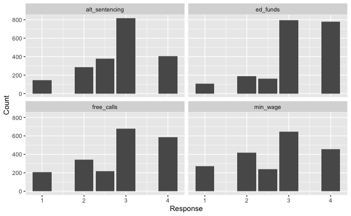

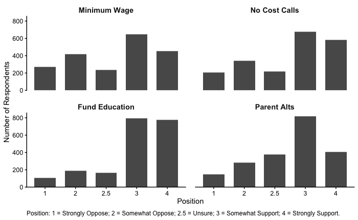

#### D5. Variance and Stand Dev

```
                min_wage free_calls  ed_funds alt_sentencing
min_wage       1.0000000  0.4831019 0.4476314      0.3850568
free_calls     0.4831019  1.0000000 0.4873705      0.3718568
ed_funds       0.4476314  0.4873705 1.0000000      0.4238443
alt_sentencing 0.3850568  0.3718568 0.4238443      1.0000000
Call:psych::corr.test(x = q25_help_data)
Correlation matrix
               min_wage free_calls ed_funds alt_sentencing
min_wage           1.00       0.48     0.45           0.39
free_calls         0.48       1.00     0.49           0.37
ed_funds           0.45       0.49     1.00           0.42
alt_sentencing     0.39       0.37     0.42           1.00
Sample Size
               min_wage free_calls ed_funds alt_sentencing
min_wage           2030       2030     2029           2029
free_calls         2030       2030     2029           2029
ed_funds           2029       2029     2029           2029
alt_sentencing     2029       2029     2029           2029
Probability values (Entries above the diagonal are adjusted for multiple tests.)
               min_wage free_calls ed_funds alt_sentencing
min_wage              0          0        0              0
free_calls            0          0        0              0
ed_funds              0          0        0              0
alt_sentencing        0          0        0              0

 To see confidence intervals of the correlations, print with the short=FALSE option

Reliability analysis
Call: psych::alpha(x = q25_help_data)

  raw_alpha std.alpha G6(smc) average_r S/N    ase mean   sd median_r
      0.75      0.75     0.7      0.43 3.1 0.0083  2.9 0.67     0.44

    95% confidence boundaries
         lower alpha upper
Feldt     0.74  0.75  0.77
Duhachek  0.74  0.75  0.77

 Reliability if an item is dropped:
               raw_alpha std.alpha G6(smc) average_r S/N alpha se   var.r med.r
```

[output cut: 11 more lines]

```

Non missing response frequency for each item
                  1    2  2.5    3    4 miss
min_wage       0.13 0.21 0.12 0.32 0.22 0.13
free_calls     0.10 0.17 0.11 0.33 0.29 0.13
ed_funds       0.05 0.09 0.08 0.39 0.38 0.13
alt_sentencing 0.07 0.14 0.19 0.40 0.20 0.13
                min_wage free_calls  ed_funds alt_sentencing
min_wage       1.0000000  0.4831019 0.4476314      0.3850568
free_calls     0.4831019  1.0000000 0.4873705      0.3718568
ed_funds       0.4476314  0.4873705 1.0000000      0.4238443
alt_sentencing 0.3850568  0.3718568 0.4238443      1.0000000

Reliability analysis
Call: psych::alpha(x = q25_help_data, check.keys = FALSE)
```

|  | raw_alpha | std.alpha | G6(smc) | average_r | S/N | ase | mean | sd | median_r |
| --- | --- | --- | --- | --- | --- | --- | --- | --- | --- |
|  | 0.7526898 | 0.7534797 | 0.6995406 | 0.4331436 | 3.056461 | 0.008286175 | 2.880296 | 0.6673166 | 0.4357378 |

```
    95% confidence boundaries
```

|  | lower | alpha | upper |
| --- | --- | --- | --- |
| Feldt | 0.74 | 0.75 | 0.77 |
| Duhachek | 0.74 | 0.75 | 0.77 |

```
 Reliability if an item is dropped:
```

|  | raw_alpha | std.alpha | G6(smc) | average_r | S/N | alpha se | var.r | med.r |
| --- | --- | --- | --- | --- | --- | --- | --- | --- |
| min_wage | 0.6898954 | 0.6915408 | 0.6033418 | 0.4276905 | 2.241919 | 0.011058204 | 0.0033469500 | 0.4238443 |
| free_calls | 0.6808464 | 0.6837571 | 0.5916732 | 0.4188442 | 2.162127 | 0.011370124 | 0.0009976434 | 0.4238443 |
| ed_funds | 0.6793238 | 0.6788368 | 0.5893460 | 0.4133385 | 2.113682 | 0.011332516 | 0.0036937609 | 0.3850568 |
| alt_sentencing | 0.7273210 | 0.7289514 | 0.6425767 | 0.4727013 | 2.689375 | 0.009728101 | 0.0004759309 | 0.4831019 |

```
 Item statistics
```

|  | n | raw.r | std.r | r.cor | r.drop | mean | sd |
| --- | --- | --- | --- | --- | --- | --- | --- |
| min_wage | 2030 | 0.7793052 | 0.7635879 | 0.6435712 | 0.5601338 | 2.690148 | 0.9493332 |
| free_calls | 2030 | 0.7845235 | 0.7723387 | 0.6626005 | 0.5743239 | 2.862069 | 0.9330415 |
| ed_funds | 2029 | 0.7675223 | 0.7777848 | 0.6693605 | 0.5806060 | 3.144406 | 0.8289894 |
| alt_sentencing | 2029 | 0.6992727 | 0.7190636 | 0.5610365 | 0.4869980 | 2.824544 | 0.8029586 |

```
Non missing response frequency for each item
                  1    2  2.5    3    4 miss
min_wage       0.13 0.21 0.12 0.32 0.22 0.13
free_calls     0.10 0.17 0.11 0.33 0.29 0.13
ed_funds       0.05 0.09 0.08 0.39 0.38 0.13
alt_sentencing 0.07 0.14 0.19 0.40 0.20 0.13
                min_wage free_calls  ed_funds alt_sentencing
min_wage       1.0000000  0.4831019 0.4476314      0.3850568
free_calls     0.4831019  1.0000000 0.4873705      0.3718568
ed_funds       0.4476314  0.4873705 1.0000000      0.4238443
alt_sentencing 0.3850568  0.3718568 0.4238443      1.0000000
```

## Police

```
character(0)
```

# Civics

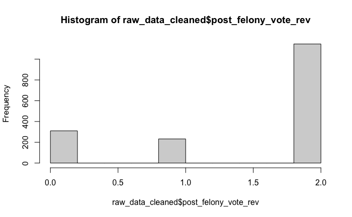

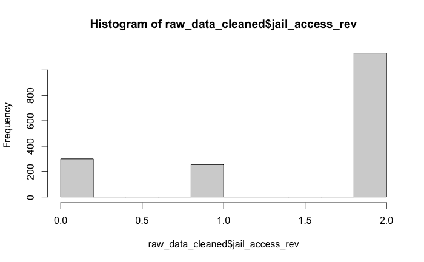

```
   Min. 1st Qu.  Median    Mean 3rd Qu.    Max.     NAs
  0.000   1.000   2.000   1.495   2.000   2.000     639
   Min. 1st Qu.  Median    Mean 3rd Qu.    Max.     NAs
  0.000   1.000   2.000   1.493   2.000   2.000     639
```

Note:

# Write and Save Data

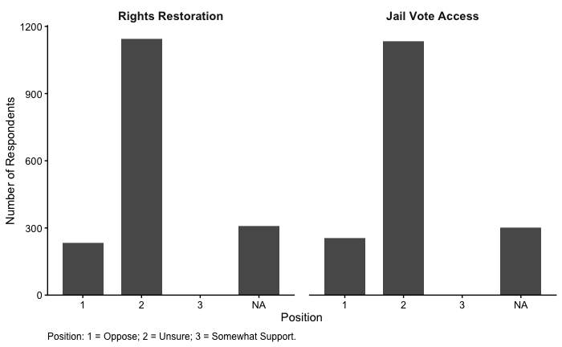